# [시계열팀]김동환_클린업_2주차_패키지

```python
!sudo apt-get install -y fonts-nanum
!sudo fc-cache -fv
!rm ~/.cache/matplotlib -rf
```

[output not shown]

```python
import pandas as pd
import numpy as np
import matplotlib.pyplot as plt
import seaborn as sns
import warnings
import io
warnings.filterwarnings('ignore')
plt.rc('font', family='NanumBarunGothic')
```

### 문제1

```python
from google.colab import files
file_uploaded = files.upload()
```

Upload widget is only available when the cell has been executed in the current browser session. Please rerun this cell to enable.

```
Saving train.csv to train.csv
```

```python
file_uploaded2=files.upload()
```

Upload widget is only available when the cell has been executed in the current browser session. Please rerun this cell to enable.

```
Saving test.csv to test.csv
```

## train data 살펴보기

```python
train = pd.read_csv(io.BytesIO(file_uploaded['train.csv']))
train.head()
```

|  | ID_code | price | carat | cut | color | clarity | depth | table | x | y | z |
| --- | --- | --- | --- | --- | --- | --- | --- | --- | --- | --- | --- |
| 0 | train_1 | 878 | 0.30 | Premium | G | VVS2 | 62.9 | 55.0 | 4.28 | 4.24 | 2.68 |
| 1 | train_2 | 3183 | 0.70 | Premium | D | VS1 | 60.9 | 60.0 | 5.75 | 5.71 | 3.49 |
| 2 | train_3 | 624 | 0.30 | Ideal | G | VS1 | 62.0 | 56.0 | 4.29 | 4.32 | 2.67 |
| 3 | train_4 | 743 | 0.33 | Premium | H | VS1 | 61.9 | 58.0 | 4.45 | 4.43 | 2.75 |
| 4 | train_5 | 526 | 0.25 | Very Good | F | IF | 63.3 | 59.0 | 3.99 | 4.04 | 2.54 |

```python
train.info()
```

```
<class 'pandas.core.frame.DataFrame'>
RangeIndex: 21707 entries, 0 to 21706
Data columns (total 11 columns):
 #   Column   Non-Null Count  Dtype
---  ------   --------------  -----
 0   ID_code  21707 non-null  object
 1   price    21707 non-null  int64
 2   carat    21707 non-null  float64
 3   cut      21707 non-null  object
 4   color    21707 non-null  object
 5   clarity  21707 non-null  object
 6   depth    21010 non-null  float64
 7   table    21707 non-null  float64
 8   x        21707 non-null  float64
 9   y        21707 non-null  float64
 10  z        21707 non-null  float64
dtypes: float64(6), int64(1), object(4)
memory usage: 1.8+ MB
```

```python
train.describe(include='all')
```

|  | ID_code | price | carat | cut | color | clarity | depth | table | x | y | z |
| --- | --- | --- | --- | --- | --- | --- | --- | --- | --- | --- | --- |
| count | 21707 | 21707.000000 | 21707.000000 | 21707 | 21707 | 21707 | 21010.000000 | 21707.000000 | 21707.000000 | 21707.000000 | 21707.000000 |
| unique | 21707 | NaN | NaN | 5 | 7 | 8 | NaN | NaN | NaN | NaN | NaN |
| top | train_1 | NaN | NaN | Ideal | G | SI1 | NaN | NaN | NaN | NaN | NaN |
| freq | 1 | NaN | NaN | 8687 | 4560 | 5277 | NaN | NaN | NaN | NaN | NaN |
| mean | NaN | 3939.077487 | 0.798718 | NaN | NaN | NaN | 61.748415 | 57.457350 | 5.732041 | 5.733807 | 3.539983 |
| std | NaN | 4009.460040 | 0.475534 | NaN | NaN | NaN | 1.410605 | 2.239175 | 1.125419 | 1.117037 | 0.722429 |
| min | NaN | 326.000000 | 0.200000 | NaN | NaN | NaN | 50.800000 | 49.000000 | 0.000000 | 0.000000 | 0.000000 |
| 25% | NaN | 949.000000 | 0.400000 | NaN | NaN | NaN | 61.000000 | 56.000000 | 4.710000 | 4.720000 | 2.910000 |
| 50% | NaN | 2387.000000 | 0.700000 | NaN | NaN | NaN | 61.800000 | 57.000000 | 5.700000 | 5.710000 | 3.520000 |
| 75% | NaN | 5355.500000 | 1.050000 | NaN | NaN | NaN | 62.500000 | 59.000000 | 6.540000 | 6.540000 | 4.040000 |
| max | NaN | 18818.000000 | 4.500000 | NaN | NaN | NaN | 73.600000 | 79.000000 | 10.230000 | 10.160000 | 31.800000 |

```python
test = pd.read_csv(io.BytesIO(file_uploaded2['test.csv']))
test.head()
```

|  | ID_code | carat | cut | color | clarity | depth | table | x | y | z |
| --- | --- | --- | --- | --- | --- | --- | --- | --- | --- | --- |
| 0 | test_1 | 1.10 | Very Good | F | SI1 | 60.5 | 60.0 | 6.65 | 6.67 | 4.03 |
| 1 | test_2 | 0.41 | Good | E | SI2 | 63.5 | 55.0 | 4.69 | 4.73 | 2.99 |
| 2 | test_3 | 0.25 | Premium | H | VVS1 | 59.8 | 59.0 | 4.07 | 4.09 | 2.44 |
| 3 | test_4 | 1.52 | Ideal | H | VVS2 | 62.8 | 56.0 | 7.32 | 7.30 | 4.59 |
| 4 | test_5 | 0.42 | Ideal | D | VVS2 | 62.1 | 55.0 | 4.78 | 4.81 | 2.98 |

```python
test.info()
```

```
<class 'pandas.core.frame.DataFrame'>
RangeIndex: 5260 entries, 0 to 5259
Data columns (total 10 columns):
 #   Column   Non-Null Count  Dtype
---  ------   --------------  -----
 0   ID_code  5260 non-null   object
 1   carat    5260 non-null   float64
 2   cut      5260 non-null   object
 3   color    5260 non-null   object
 4   clarity  5260 non-null   object
 5   depth    5260 non-null   float64
 6   table    5260 non-null   float64
 7   x        5260 non-null   float64
 8   y        5260 non-null   float64
 9   z        5260 non-null   float64
dtypes: float64(6), object(4)
memory usage: 411.1+ KB
```

```python
test.describe(include='all')
```

|  | ID_code | carat | cut | color | clarity | depth | table | x | y | z |
| --- | --- | --- | --- | --- | --- | --- | --- | --- | --- | --- |
| count | 5260 | 5260.00000 | 5260 | 5260 | 5260 | 5260.000000 | 5260.000000 | 5260.000000 | 5260.000000 | 5260.000000 |
| unique | 5260 | NaN | 5 | 7 | 8 | NaN | NaN | NaN | NaN | NaN |
| top | test_1 | NaN | Ideal | G | SI1 | NaN | NaN | NaN | NaN | NaN |
| freq | 1 | NaN | 2129 | 1101 | 1294 | NaN | NaN | NaN | NaN | NaN |
| mean | NaN | 0.79696 | NaN | NaN | NaN | 61.732091 | 57.450837 | 5.720827 | 5.732586 | 3.530110 |
| std | NaN | 0.48681 | NaN | NaN | NaN | 1.421892 | 2.202700 | 1.141274 | 1.349770 | 0.713139 |
| min | NaN | 0.20000 | NaN | NaN | NaN | 52.200000 | 49.000000 | 3.770000 | 3.720000 | 0.000000 |
| 25% | NaN | 0.39000 | NaN | NaN | NaN | 61.000000 | 56.000000 | 4.680000 | 4.690000 | 2.890000 |
| 50% | NaN | 0.70000 | NaN | NaN | NaN | 61.800000 | 57.000000 | 5.675000 | 5.680000 | 3.500000 |
| 75% | NaN | 1.05000 | NaN | NaN | NaN | 62.500000 | 59.000000 | 6.550000 | 6.550000 | 4.040000 |
| max | NaN | 4.00000 | NaN | NaN | NaN | 72.200000 | 68.000000 | 10.010000 | 58.900000 | 8.060000 |

## 문제2

```python
#drop을 이용해서 ID_code col 드랍하기
train.drop('ID_code',axis=1,inplace=True)
test.drop('ID_code',axis=1,inplace=True)
```

```python
#정상적으로 제거 되었나 확인인
print(train.columns)
print(test.columns)
```

```
Index(['price', 'carat', 'cut', 'color', 'clarity', 'depth', 'table', 'x', 'y',
       'z'],
      dtype='object')
Index(['carat', 'cut', 'color', 'clarity', 'depth', 'table', 'x', 'y', 'z'], dtype='object')
```

## 문제3

```python
import missingno as msno
```

```python
train.isna().sum()
```

```
price        0
carat        0
cut          0
color        0
clarity      0
depth      697
table        0
x            0
y            0
z            0
dtype: int64
```

```python
test.isna().sum()
```

```
carat      0
cut        0
color      0
clarity    0
depth      0
table      0
x          0
y          0
z          0
dtype: int64
```

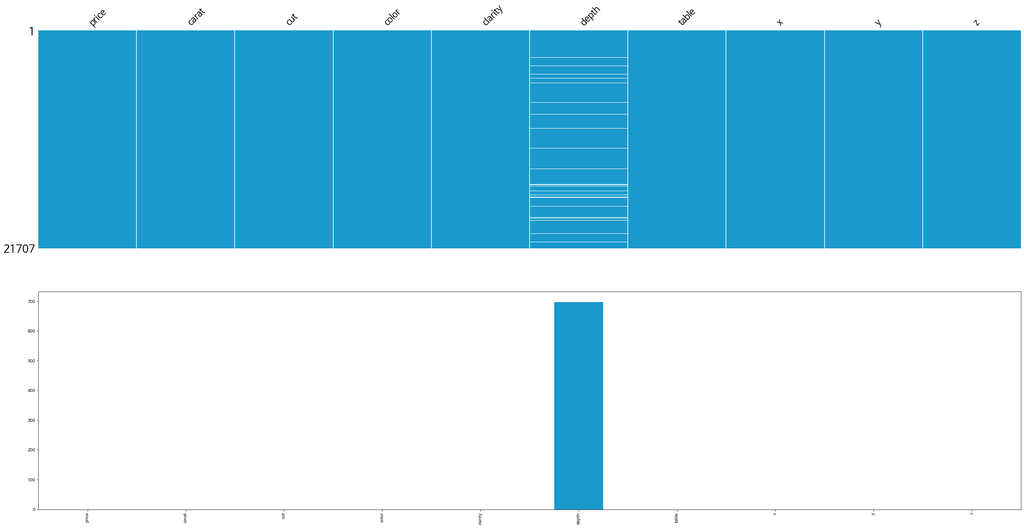

```python
fig,axes = plt.subplots(2,1,figsize=(40,20))
msno.matrix(train,color=(0.1,0.6,0.8),ax=axes[0],fontsize=20)
missing = train.isnull().sum()
missing.plot.bar(color=(0.1,0.6,0.8))
plt.show()
```

## 문제4

```python
num_columns = train.select_dtypes(include=np.number).columns.tolist()
print('수치형 변수는 {}입니다.'.format(num_columns))
cat_columns = train.select_dtypes(exclude=np.number).columns.tolist()
print('범주형 변수는 {}입니다.'.format(cat_columns))
```

```
수치형 변수는 ['price', 'carat', 'depth', 'table', 'x', 'y', 'z']입니다.
범주형 변수는 ['cut', 'color', 'clarity']입니다.
```

- 수치형자료 : 키, 몸무게 등 숫자형태로 측정되는 자료.
- 범주형자료 : 성별(남,여), 선호도(싫음,좋음)등,몇개의 범주를 갖는 형태로 측정되는 자료.

## 문제5

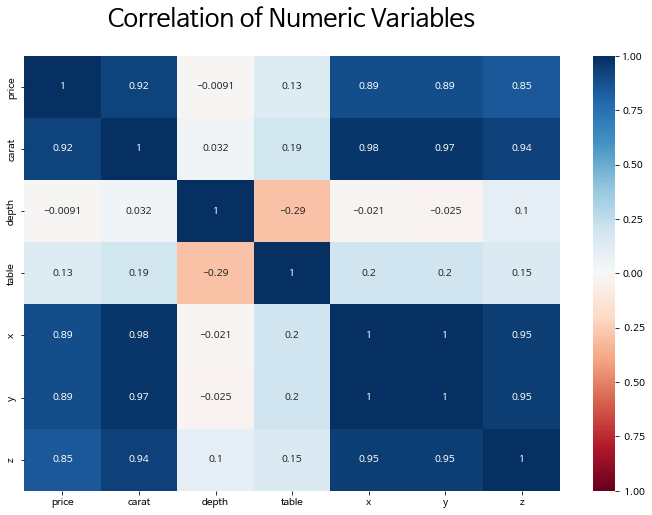

```python
corr=train[num_columns].corr()
fig=plt.figure(figsize=(12,8))
sns.heatmap(corr,cmap='RdBu',vmin=-1,vmax=1,annot=True)
plt.title('Correlation of Numeric Variables',fontsize=25,pad=30)
plt.show()
```

- Price: depth와는 사실상 선형관계계가 없다, table과는 약한선형관계가 있다. 나머지 변수와는 매우 강한 선형관계에 있다.
- Carat: Price와 마찬가지로 depth와는 사실상 없고, table과는 약한 선형관계가 있다. 나머지 변수와는 매우 강한 선형관계에 있다.
- depth: table과 음의 선형관계가 있고, z와는 약한 선형관계에 있다. 나머지 변수와는 사실상 선형관계가 없다.
- table: 모든 변수와 약한 선형관게에 있다. depth와는 음의 선형관계에 있다.
- x: depth와는 관계가 없다. table과는 약한 선형관계에 있다. 나머지변수와는 매우매우 강한 선형관계에 있다.
- y: depth와는 관계가 없다. table과는 약한 선형관계에 있다. 나머지변수와는 매우매우 강한 선형관계에 있다.
- z: depth, table과 약한 선형관계에 있다. 나머지변수와는 매우매우 강한 선형관계에 있다.

## 보너스1

```python
from scipy import stats
```

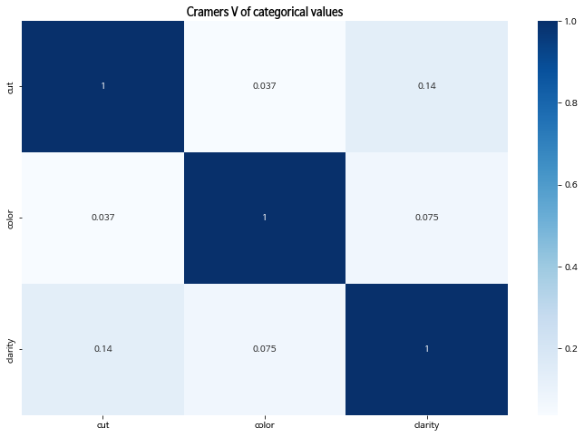

```python
cat_df=train[cat_columns]
#carmers v 계산 함수
def cramers_v(x, y):
    #교차표 만들기
    confusion_matrix = pd.crosstab(x, y)
    #카이제곱값 계산하기
    chi2 = stats.chi2_contingency(confusion_matrix)[0]
    n = confusion_matrix.sum().sum()
    phi2 = chi2/n
    r, k = confusion_matrix.shape
    #phi2값을 보정, phi2가 음수일 경우는 0으로 처리
    phi2corr = max(0, phi2 - ((k-1)*(r-1))/(n-1))
    rcorr = r - ((r-1)**2)/(n-1)
    kcorr = k - ((k-1)**2)/(n-1)
    #carmers v반환
    return np.sqrt(phi2corr / min((kcorr-1), (rcorr-1)))

cramers_v_matrix = np.array([[cramers_v(cat_df[column1], cat_df[column2]) for column1 in cat_columns] for column2 in cat_columns])
cramers_v_df = pd.DataFrame(cramers_v_matrix, columns=cat_columns, index=cat_columns)
plt.figure(figsize=(12,8))
sns.heatmap(cramers_v_df, annot=True, cmap='Blues')
plt.title('Cramers V of categorical values' ,fontweight='bold')
plt.show()
```

## 문제6

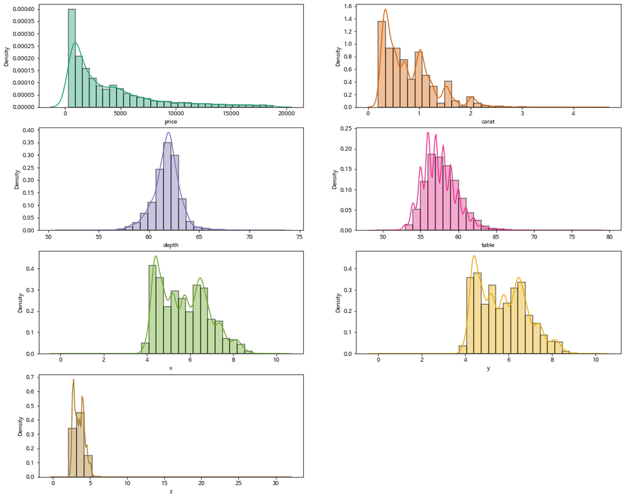

```python
palette=sns.color_palette('Dark2')
fig, axes = plt.subplots(nrows=4, ncols=2, figsize=(18,15))
#yticks 설정정
yticks_list = [np.arange(0, 0.00045, 0.00005), np.arange(0, 1.8, 0.2),
               np.arange(0, 0.45, 0.05), np.arange(0, 0.3, 0.05),
               np.arange(0, 0.5, 0.1), np.arange(0, 0.5, 0.1),np.arange(0, 0.8, 0.1)]
#axes저장장
ax=[axes[0,0],axes[0,1],axes[1,0],axes[1, 1],axes[2, 0],axes[2, 1],axes[3, 0]]
#그래프그리기기
for i in range(len(num_columns)):
  sns.distplot(train[num_columns[i]],bins=30,hist_kws=dict(edgecolor="black", linewidth=2),color=palette[i], ax=ax[i])
  ax[i].set_yticks(yticks_list[i])
#비어있는 곳은 안보이게게
axes[3, 1].axis('off')
plt.show()
```

## 문제7

```python
mean_color=train.groupby('color').mean()['price']
mean_cut=train.groupby('cut').mean()['price']
mean_clarity=train.groupby('clarity').mean()['price']
```

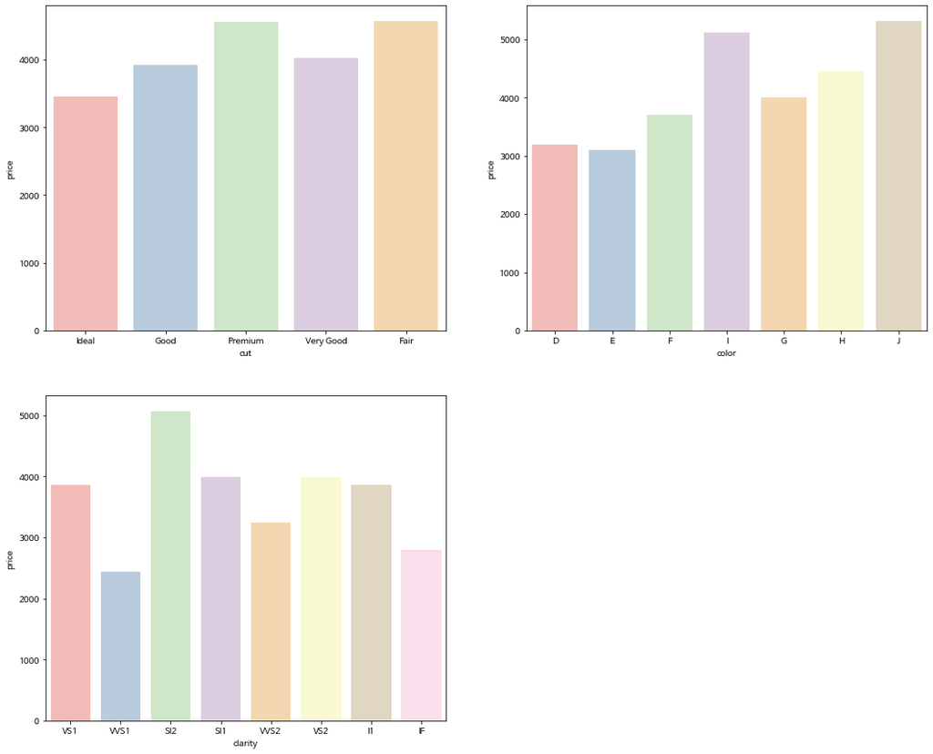

```python
palette=sns.color_palette('Pastel1')
plt.figure(figsize=(18,15))
plt.subplot(2,2,1)
sns.barplot(x=mean_cut.index,y=mean_cut,palette=palette,ci=95,order=['Ideal','Good','Premium','Very Good','Fair'])
plt.subplot(2,2,2)
sns.barplot(x=mean_color.index,y=mean_color,palette=palette,order=['D','E','F','I','G','H','J'])
plt.subplot(2,2,3)
sns.barplot(x=mean_clarity.index,y=mean_clarity,palette=palette,order=['VS1','VVS1','SI2','SI1','VVS2','VS2','I1','IF'])
plt.show()
```

- cut : preminum,fair이 평균적으로 가장 비싸고 나머지는 고만고만함. ideal이 가장낮음
- color : J,I의 가격이 가장 비쌈. D,E가 가장 쌈.
- clarity : SI2가 가장 비싸고 VVS1,F는 싼편이고, 나머지는 고만고만함.

## 보너스2

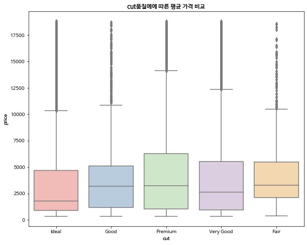

```python
fig=plt.figure(figsize=(10,8))
#boxplot그리기
sns.boxplot(x='cut',y='price',data=train,order=['Ideal','Good','Premium','Very Good','Fair'],palette=palette)
#제목,label,그래프 눈금 설정정
plt.title('cut품질에에 따른 평균 가격 비교',fontweight='bold')
plt.xlabel('cut',weight='bold')
plt.ylabel('price',weight='bold')
plt.show()
```

- cut 별 가격 분포를 대강 알 수 있음. 이상치로 보이는 부분이 매우 많이 보이기는 하지만, 너무 양이 많아 함부로 제거하기는 어려워보임. 추후 모델 적합 후, features_importance가 높다면, 이상치에 대한 조치를 해야할 수 도 있음.

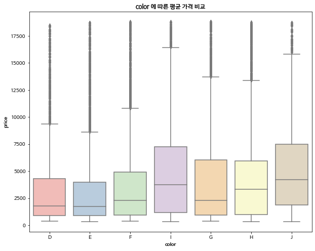

```python
fig=plt.figure(figsize=(10,8))
#boxplot그리기
sns.boxplot(x='color',y='price',data=train,palette=palette,order=['D','E','F','I','G','H','J'])
#제목,label,그래프 눈금 설정정
plt.title('color 에 따른 평균 가격 비교',fontweight='bold')
plt.xlabel('color',weight='bold')
plt.ylabel('price',weight='bold')
plt.show()
```

## 문제8

- Test Data와 Train Data에 동일한 전처리를 진행해야 하는 이유:

모델 학습 시 사용하는 Train Set과 모델 성능을 평가하는 Test Set간의 일관성을 유지하기 위함임. 두 세트의 전처리를 다르게 진행하면 모델은 Train set에서는 동작하지만 Test set에서는 동작하지 않을 수 있음. 예를 들어, Train set에서는 결측치를 평균값으로 대체했다면, Test set에서도 결측치를 평균값으로 대체해야 함함. 만약 Test set에서는 결측치를 0으로 대체한다면, 모델은 Train set에서 학습한 방식과 달라져서 예측 성능이 떨어질 수 있음.

- Data Leakage : 모델이 값을 예측 할 때 사용되지 않았어야 할 정보가 모델링에 사용되는 경우 발생함. 이 경우 모델이 현재 가지고 있지 않는 미래의 데이터를 예측 할 때, 모델의 성능을 과대평가하게 되는 문제가 발생할 수 있음. Data Leakage는 모델링의 결과를 왜곡시켜 결과적으로 제대로 작동하지 않을 가능성이 높아짐.

## 문제9

```python
#평균값으로 결측치 대체
#test데이터는 결측치 없음
mean_depth=train['depth'].mean()
train['depth']=train['depth'].fillna(mean_depth)
train.isna().sum()
```

```
price      0
carat      0
cut        0
color      0
clarity    0
depth      0
table      0
x          0
y          0
z          0
dtype: int64
```

## 문제10

```python
from sklearn.preprocessing import LabelEncoder
```

```python
le=LabelEncoder()
for col in cat_columns:
  train[col+'_encoded']=le.fit_transform(train[col])
  test[col+'_encoded']=le.fit_transform(test[col])
```

## 보너스3

- 평균값 대체법 (Mean Imputation) : 결측치를 해당 변수의 전체 데이터의 평균값으로 대체
- 최빈값 대체법 (Mode Imputation) : 주로 범주형 데이터에서 결측치를 해당 변수의 전체 데이터에서 가장 자주 등장하는 값으로 대체
- 회귀 대체법 (Regression Imputation) : 다른 변수들과의 관계를 이용하여 결측치를 예측. 단순 선형 회귀, 다중 선형 회귀, 로지스틱 회귀 등을 이용하여 결측치를 예측함.

## 보너스4

```python
#부피 x*y*z
#일반적으로 크기과 가격은 양의 상관이고 x,y,z의 상관관계가 너무높아서 뭔가 처리를 해야했음
train['v']=train['x']*train['y']*train['z']
test['v']=test['x']*test['y']*test['z']
```

```python
train.columns
```

```
Index(['price', 'carat', 'cut', 'color', 'clarity', 'depth', 'table', 'x', 'y',
       'z', 'cut_encoded', 'color_encoded', 'clarity_encoded', 'v'],
      dtype='object')
```

```python
test.columns
```

```
Index(['carat', 'cut', 'color', 'clarity', 'depth', 'table', 'x', 'y', 'z',
       'cut_encoded', 'color_encoded', 'clarity_encoded', 'v'],
      dtype='object')
```

```python
custom_train=train[['price', 'carat','depth', 'table','cut_encoded', 'color_encoded', 'clarity_encoded', 'v']]
custom_test=test[['carat','depth', 'table','cut_encoded', 'color_encoded', 'clarity_encoded', 'v']]
```

```python
custom_train.head()
```

|  | price | carat | depth | table | cut_encoded | color_encoded | clarity_encoded | v |
| --- | --- | --- | --- | --- | --- | --- | --- | --- |
| 0 | 878 | 0.30 | 62.9 | 55.0 | 3 | 3 | 7 | 48.634496 |
| 1 | 3183 | 0.70 | 60.9 | 60.0 | 3 | 0 | 4 | 114.585425 |
| 2 | 624 | 0.30 | 62.0 | 56.0 | 2 | 3 | 4 | 49.482576 |
| 3 | 743 | 0.33 | 61.9 | 58.0 | 3 | 4 | 4 | 54.212125 |
| 4 | 526 | 0.25 | 63.3 | 59.0 | 4 | 2 | 1 | 40.943784 |

```python
custom_test.head()
```

|  | carat | depth | table | cut_encoded | color_encoded | clarity_encoded | v |
| --- | --- | --- | --- | --- | --- | --- | --- |
| 0 | 1.10 | 60.5 | 60.0 | 4 | 2 | 2 | 178.752665 |
| 1 | 0.41 | 63.5 | 55.0 | 1 | 1 | 3 | 66.329263 |
| 2 | 0.25 | 59.8 | 59.0 | 3 | 4 | 6 | 40.616972 |
| 3 | 1.52 | 62.8 | 56.0 | 2 | 4 | 7 | 245.271240 |
| 4 | 0.42 | 62.1 | 55.0 | 2 | 0 | 7 | 68.515564 |

### Chapter 2 : XGBoost & LightGBM

## 문제1

```python
def seed_everything(seed: int = 3031):
    random.seed(seed)
    np.random.seed(seed)
    os.environ["PYTHONHASHSEED"] = str(seed)
    tf.random.set_seed(seed)
```

## 문제2

```python
from sklearn.model_selection import KFold
```

```python
train_target=custom_train[['price']]
train_data=custom_train.drop('price',axis=1)
```

```python
test_data=custom_test.copy()
```

```python
kf = KFold(n_splits=5)
for train_index, test_index in kf.split(train_data):
    X_train, X_test = train_data.iloc[train_index], train_data.iloc[test_index]
    y_train, y_test = train_target.iloc[train_index], train_target.iloc[test_index]
```

- XGBoost(Extreme Gradient Boosting)와 LightGBM(Light Gradient Boosting Machine)은 모두 Gradient Boosting 알고리즘을 기반으로 한 머신러닝 모델임임. Gradient Boosting은 이전 트리의 예측 오차를 현재 트리의 입력값으로 사용하여, 새로운 트리를 만들어 예측 오차를 줄여나가는 알고리즘으로 두 모델 모두 이 알고리즘을 기반으로 함.
- 두 모델은 트리를 분기에 차이점이 있음. XGBoost는 가지치기(Pruning)를 사용하는 반면, LightGBM은 리프 중심 히스토그램 기반의 분할 방식을 사용함.
- 가지치기는 트리의 깊이를 일정 수준까지 제한하여 과적합을 방지하는 방식으로로 트리의 모든 가지를 계속 확장하는 것이 아니라, 노드에서 특정 기준을 만족하는 경우에만 가지를 확장하고, 그 이하의 분기는 더 이상 진행하지 않음. 이를 통해 불필요한 분기를 방지하고, 모델의 일반화 성능을 높임.
- 리프 중심 히스토그램 방식은 데이터의 분포를 히스토그램으로 구성하여, 각 구간에서의 레이블 빈도수를 계산한 뒤, 레이블 빈도수가 높은 구간을 먼저 분할하는 방식임임. 이를 통해 불필요한 분기를 최소화하고, 모델의 학습 속도를 높일 수 있음.

## 문제3

```python
from xgboost import XGBRegressor
from lightgbm import LGBMRegressor
```

## 문제4

- XGBoost와 LightGBM 모델에서 사용되는 하이퍼파라미터 중 일부는 다음과 같음.
- max_depth: 트리의 최대 깊이를 제한함. XGBoost와 LightGBM 모두 파라미터 이름은 max_depth로 사용함. (사이킷런 API도 동일). XGBoost의 디폴트 값은 6이고, LightGBM의 디폴트 값은 -1임.
- number iterations: 말 그대로 반복 횟수로 모델 성능, 학습시간, 램 사용량등에 영향을 줌. 큰 값을 넣고 early stop을 함계 사용하곤 함. 사이킷런 API에서는 모두 n_estimators로 사용 가능능
- max_leaves: 트리의 최대 잎수를 제한함. 트리의 최대 깊이, 모형 성능, 학습 속도 등에 영향을 줌. Maximum Leaves의 파라미터명은 xgboost에서는 max_leaves, lightgbm에서는 num_leaves입니다. xgboost의 디폴트 값은 255이고, lightgbm의 디폴트 값은 31임.

## 문제5,7

```python
from sklearn.model_selection import GridSearchCV
from sklearn.metrics import mean_squared_error,make_scorer
```

```python
#rmse평가지표로 만들기기
rmse = make_scorer(lambda y_true, y_pred: np.sqrt(mean_squared_error(y_true, y_pred)), greater_is_better=False)
```

```python
xgb = XGBRegressor()
lgb = LGBMRegressor()
params ={'n_estimators':[300, 400, 500], 'max_depth':[2,4,6],
'learning_rate' : [0.05,0.1,0.2]}
```

```python
#refit으로 7번 문제도 한번에 했습니다.
gslgb = GridSearchCV(lgb,param_grid=params,cv=kf,refit=True,scoring=rmse)
gslgb.fit(train_data,train_target)
```

```
GridSearchCV(cv=KFold(n_splits=5, random_state=None, shuffle=False),
             estimator=LGBMRegressor(),
             param_grid={'learning_rate': [0.05, 0.1, 0.2],
                         'max_depth': [2, 4, 6],
                         'n_estimators': [300, 400, 500]},
             scoring=make_scorer(<lambda>, greater_is_better=False))
```

```python
gsxgb = GridSearchCV(xgb,param_grid=params,cv=kf,refit=True,scoring=rmse)
gsxgb.fit(train_data,train_target)
```

```
GridSearchCV(cv=KFold(n_splits=5, random_state=None, shuffle=False),
             estimator=XGBRegressor(base_score=None, booster=None,
                                    callbacks=None, colsample_bylevel=None,
                                    colsample_bynode=None,
                                    colsample_bytree=None,
                                    early_stopping_rounds=None,
                                    enable_categorical=False, eval_metric=None,
                                    feature_types=None, gamma=None, gpu_id=None,
                                    grow_policy=None, importance_type=None,
                                    i...
                                    max_cat_to_onehot=None, max_delta_step=None,
                                    max_depth=None, max_leaves=None,
                                    min_child_weight=None, missing=nan,
                                    monotone_constraints=None, n_estimators=100,
                                    n_jobs=None, num_parallel_tree=None,
                                    predictor=None, random_state=None, ...),
             param_grid={'learning_rate': [0.05, 0.1, 0.2],
                         'max_depth': [2, 4, 6],
                         'n_estimators': [300, 400, 500]},
             scoring=make_scorer(<lambda>, greater_is_better=False))
```

```python
gsxgb.best_params_
```

```
{'learning_rate': 0.05, 'max_depth': 6, 'n_estimators': 400}
```

```python
gslgb.best_params_
```

```
{'learning_rate': 0.05, 'max_depth': 6, 'n_estimators': 500}
```

## 문제8

```python
feat_impxgb=pd.DataFrame(gsxgb.best_estimator_.feature_importances_,index=train_data.columns,columns=['value'])
feat_impxgb=feat_impxgb.sort_values(by=['value'],ascending=False)
feat_implgb=pd.DataFrame(gslgb.best_estimator_.feature_importances_,index=train_data.columns,columns=['value'])
feat_implgb=feat_implgb.sort_values(by=['value'],ascending=False)
```

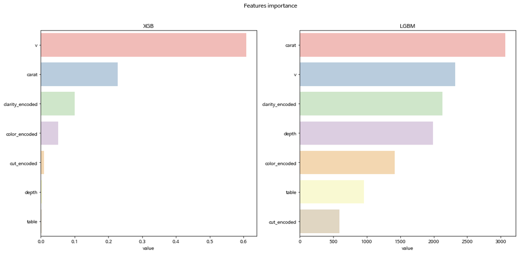

```python
fig, axes = plt.subplots(1,2,figsize=(18,8))
fig.suptitle('Features importance')
sns.barplot(x=feat_impxgb['value'],y=feat_impxgb.index,palette=palette,ax=axes[0])
axes[0].set_title('XGB')
sns.barplot(x=feat_implgb['value'],y=feat_implgb.index,palette=palette,ax=axes[1])
axes[1].set_title('LGBM')
plt.show()
```

- 모델에 따라 변수 중요도에 차이가 있으나 예상 가능했듯이 무게와, 부피가 역시나 가격에는 큰 영향을 미치는 것을 보임.

## 문제9

```python
file_uploaded3 = files.upload()
```

Upload widget is only available when the cell has been executed in the current browser session. Please rerun this cell to enable.

```
Saving sample_submission.csv to sample_submission.csv
```

```python
file_uploaded4 = files.upload()
```

Upload widget is only available when the cell has been executed in the current browser session. Please rerun this cell to enable.

```
Saving answer.csv to answer.csv
```

```python
sample_submission = pd.read_csv(io.BytesIO(file_uploaded3['sample_submission.csv']))
answer = pd.read_csv(io.BytesIO(file_uploaded4['answer.csv']))
```

```python
#xgb예측값
sol_xgb=sample_submission.copy()
sol_xgb['price']=gsxgb.predict(test_data)
```

```python
#lgb예측값
sol_lgb=sample_submission.copy()
sol_lgb['price']=gslgb.predict(test_data)
```

```python
#rmse 함수 만들기
def rmse_value(y_true, y_pred):
    mse = mean_squared_error(y_true, y_pred)
    return(np.sqrt(mse))
```

```python
xgb_true_score=rmse_value(answer['price'],sol_xgb['price'])
xgb_cv_score=gsxgb.best_score_
lgb_true_score=rmse_value(answer['price'],sol_lgb['price'])
lgb_cv_score=gslgb.best_score_
```

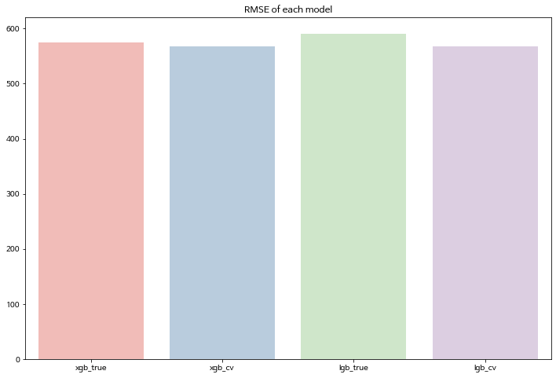

```python
plt.figure(figsize=(12,8))
sns.barplot(x=['xgb_true','xgb_cv','lgb_true','lgb_cv'],y=[xgb_true_score,-xgb_cv_score,lgb_true_score,-lgb_cv_score],palette=palette)
plt.title('RMSE of each model')
plt.show()
```

## 보너스5

- 앙상블 기법(Ensemble technique)은 여러 개의 예측 모델을 결합하여 보다 정확한 예측을 수행하는 기법임. 이는 개별 모델의 한계를 극복하고, 모델 간의 상호보완을 통해 전체적인 성능을 향상시키는 데에 응용됨. 그 종류에는 여러가지가 있지만, 몇가지만 소개하면 다음과 같음.
1. Voting: 다수결 방식으로 여러 모델의 예측 결과를 투표하여 가장 많이 선택된 결과를 선택하는 방법임. 하드 보팅(Hard Voting)은 단순한 투표 방식이고, 소프트 보팅(Soft Voting)은 예측 확률을 평균내어 선택함.
2. Bagging: 데이터 샘플을 랜덤하게 선택하여 모델을 학습시키는 방법으로로 각 모델은 다른 데이터 샘플을 학습하며, 이를 통해 다양한 모델을 생성하여 성능을 향상시킴. 대표적인 예로 Random Forest가 있음.
3. Boosting: 약한 모델을 연속적으로 학습시켜 강한 모델을 만드는 방법으로 이전 모델이 예측을 잘못한 데이터에 가중치를 부여하여 다음 모델이 이를 보완하도록 함. 대표적인 예로 AdaBoost, Gradient Boosting, XGBoost가 있음.

## 보너스6

```python
mean_xl = sample_submission.copy()
```

```python
#lgb평균값으로 대체하고 rmse구하기
mean_xl['price']=sol_lgb['price'].mean()
rmse_value(answer['price'],mean_xl['price'])
```

```
4087.823659335521
```

```python
#xgb평균값으로 대체하고 rmse구하기
mean_xl['price']=sol_xgb['price'].mean()
rmse_value(answer['price'],mean_xl['price'])
```

```
4087.821939754887
```

```python
# k-fold 교차 검증 수행
kf = KFold(n_splits=5)
xgb_weight_list = [0.1, 0.3, 0.5, 0.7, 0.9]  # xgb의 가중치 후보
lgb_weight_list = [0.9, 0.7, 0.5, 0.3, 0.1]  # lgb의 가중치 후보

best_weight = None
best_rmse = np.inf

for xgb_weight in xgb_weight_list:
    for lgb_weight in lgb_weight_list:
        rmse_list = []
        for train_idx, val_idx in kf.split(train_data):
            x_train, y_train = train_data.iloc[train_idx,], train_target.iloc[train_idx,]
            x_val, y_val = train_data.iloc[val_idx,], train_target.iloc[val_idx,]

            # 예측값 계산
            y_pred = gsxgb.predict(x_val)*xgb_weight+gslgb.predict(x_val)*lgb_weight

            # RMSE 계산
            rmse = np.sqrt(mean_squared_error(y_val, y_pred))
            rmse_list.append(rmse)

        # 가중치 조합별 평균 RMSE 계산
        possible_rmse = rmse

        # 최적 가중치 업데이트
        if possible_rmse < best_rmse:
            best_weight = (xgb_weight, lgb_weight)
            best_rmse = possible_rmse

print("Best weight:", best_weight)
print("Best RMSE:", best_rmse)
```

```
Best weight: (0.9, 0.1)
Best RMSE: 383.84395784262455
```